# Model

```python
import pandas as pd
import statsmodels.api as sm
from statsmodels.stats.stattools import durbin_watson
import matplotlib.pyplot as plt
from statsmodels.stats.diagnostic import het_breuschpagan
import statsmodels.api as sm
from scipy.stats import jarque_bera
from statsmodels.stats.outliers_influence import variance_inflation_factor
import seaborn as sns
from sklearn.linear_model import LinearRegression,LassoCV
from sklearn.metrics import mean_squared_error, mean_absolute_error, r2_score, make_scorer
import numpy as np
from sklearn.model_selection import train_test_split, TimeSeriesSplit, cross_val_score, RandomizedSearchCV
from sklearn.linear_model import Ridge
from sklearn.linear_model import Lasso
from xgboost import XGBRegressor
from sklearn.ensemble import RandomForestRegressor
from sklearn.model_selection import TimeSeriesSplit, cross_val_score
```

STEP 0 Load the Data set

```python
""" Import the data, handle missing values, and check column types. """

df = pd.read_excel("Excel_files\\All_Unemployment_Indicators.xlsx")

# Remove rows with NaN values
df = df.dropna()

# Define target variable / dependent
y = df["Unemployment_rate_pct"]

# Define predictors (exclude Quarter but keep it in df) , Independent
X = df.drop(columns=["Unemployment_rate_pct", "Quarter"])
# Define predictors

# Check data
print(df.head())
print(df.describe())
print(df.isnull().sum())

print("Dataset shape:", df.shape)
print(df.head())
print(X.columns)
```

```
  Quarter  GDP_growth_pct  VolumeIndex_growth_pct  Avg_weekly_hours_per_week  \
1  1995Q2        2.726223               -2.583732                  33.178689
2  1995Q3       -0.449516                0.196464                  33.515765
3  1995Q4        0.075258               -2.254902                  33.203723
4  1996Q1        1.749870                1.705115                  33.655242
5  1996Q2        0.807300                0.542406                  33.281788

   Activity_rate_pct  Inflation_yoy_pct  Index_Of_Wage  Unemployment_rate_pct  \
1              61.11           1.333333           1621              16.000000
2              61.11           0.533333           1631              14.766667
3              61.11           0.300000           1665              15.033333
4              59.36           0.533333           1681              15.266667
5              59.36           0.600000           1685              15.566667

   Economic Sentiment  Interest  Oil Price
1               109.2  8.791667  18.068871
2                98.8  8.791667  16.214844
3                87.2  8.791667  16.920000
4                85.3  7.076667  18.556875
5                88.0  7.076667  19.498197
       GDP_growth_pct  VolumeIndex_growth_pct  Avg_weekly_hours_per_week  \
count      123.000000              123.000000                 123.000000
mean         0.439042                0.345127                  31.481137
std          1.360953                2.314709                   1.109182
min         -6.520862              -11.666119                  29.358683
25%         -0.159862               -0.938455                  30.687087
50%          0.448936                0.530705                  31.418768
75%          1.118635                1.645446                  32.355129
max          4.941931                6.742739                  33.655242

       Activity_rate_pct  Inflation_yoy_pct  Index_Of_Wage  \
count         123.000000         123.000000     123.000000
mean           63.716829           1.733875    2698.178862
std             2.992980           1.770554     648.707012
min            59.360000          -0.966667    1621.000000
25%            61.030000           0.600000    2100.000000
50%            63.800000           1.233333    2782.000000
75%            66.100000           2.433333    3168.500000
max            70.500000           8.833333    3921.000000

```

[output cut: 31 more lines]

```
2              61.11           0.533333           1631              14.766667
3              61.11           0.300000           1665              15.033333
4              59.36           0.533333           1681              15.266667
5              59.36           0.600000           1685              15.566667

   Economic Sentiment  Interest  Oil Price
1               109.2  8.791667  18.068871
2                98.8  8.791667  16.214844
3                87.2  8.791667  16.920000
4                85.3  7.076667  18.556875
5                88.0  7.076667  19.498197
Index(['GDP_growth_pct', 'VolumeIndex_growth_pct', 'Avg_weekly_hours_per_week',
       'Activity_rate_pct', 'Inflation_yoy_pct', 'Index_Of_Wage',
       'Economic Sentiment', 'Interest', 'Oil Price'],
      dtype='str')
```

STEP 1 Baseline Linear Regression (OLS)

Fit a simple Ordinary Least Squares (OLS) Is a simple method used in statistics and data analysis to find the best straight line that explains the relationship  
between variables. OLS finds the straight line that fits these points the best.  
Purpose: get a first idea of how the predictors relate to the target.

```python
# Add constant for intercept
X_const = sm.add_constant(X)

# Fit OLS model
model = sm.OLS(y, X_const).fit()

print(model.summary())
```

```
                              OLS Regression Results
=================================================================================
Dep. Variable:     Unemployment_rate_pct   R-squared:                       0.615
Model:                               OLS   Adj. R-squared:                  0.585
Method:                    Least Squares   F-statistic:                     20.09
Date:                   Mon, 30 Mar 2026   Prob (F-statistic):           9.03e-20
Time:                           13:11:34   Log-Likelihood:                -211.12
No. Observations:                    123   AIC:                             442.2
Df Residuals:                        113   BIC:                             470.4
Df Model:                              9
Covariance Type:               nonrobust
=============================================================================================
                                coef    std err          t      P>|t|      [0.025      0.975]
---------------------------------------------------------------------------------------------
const                       -33.0976     27.615     -1.199      0.233     -87.807      21.612
GDP_growth_pct                0.0578      0.138      0.420      0.675      -0.215       0.330
VolumeIndex_growth_pct        0.0573      0.073      0.783      0.435      -0.088       0.202
Avg_weekly_hours_per_week     0.6070      0.748      0.811      0.419      -0.876       2.090
Activity_rate_pct             0.4407      0.106      4.165      0.000       0.231       0.650
Inflation_yoy_pct            -0.3570      0.087     -4.123      0.000      -0.529      -0.185
Index_Of_Wage                -0.0009      0.001     -0.668      0.505      -0.004       0.002
Economic Sentiment           -0.0243      0.018     -1.372      0.173      -0.059       0.011
Interest                      0.4395      0.114      3.846      0.000       0.213       0.666
Oil Price                    -0.0170      0.006     -2.732      0.007      -0.029      -0.005
==============================================================================
Omnibus:                        0.429   Durbin-Watson:                   0.904
Prob(Omnibus):                  0.807   Jarque-Bera (JB):                0.566
Skew:                           0.119   Prob(JB):                        0.753
Kurtosis:                       2.769   Cond. No.                     6.06e+05
==============================================================================

Notes:
[1] Standard Errors assume that the covariance matrix of the errors is correctly specified.
[2] The condition number is large, 6.06e+05. This might indicate that there are
strong multicollinearity or other numerical problems.
```

```python
"""
Significant Variables (Your regression suggests unemployment is mainly driven by:

| Variable          | p-value | Interpretation |
| ----------------- | ------- | -------------- |
| Activity_rate_pct | 0.000   | strong         |
| Inflation_yoy_pct | 0.000   | strong         |
| Interest          | 0.000   | strong         |
| Oil Price         | 0.007   | significant    |

Not significant variables:

| Variable               | p-value |
| ---------------------- | ------- |
| GDP_growth_pct         | 0.675   |
| VolumeIndex_growth_pct | 0.435   |
| Avg_weekly_hours       | 0.419   |
| Index_Of_Wage          | 0.505   |
| Economic Sentiment     | 0.173   |
Important: this does not mean they are useless — nonlinear models (Random Forest) may still use them.
"""
```

```
'\nSignificant Variables (Your regression suggests unemployment is mainly driven by:\n\n| Variable          | p-value | Interpretation |\n| ----------------- | ------- | -------------- |\n| Activity_rate_pct | 0.000   | strong         |\n| Inflation_yoy_pct | 0.000   | strong         |\n| Interest  …
```

STEP 2 Check Model Assumptions / Errors

### a) Durbin-Watson Test (Independent Errors)

The Durbin-Watson test checks if the residuals (errors) in a regression are independent over time.

```python
dw = durbin_watson(model.resid)
print("Durbin-Watson statistic:", dw)
```

```
Durbin-Watson statistic: 0.9044218543799177
```

```python
"""
How to interpret the result
Durbin-Watson	Interpretation
~2	No autocorrelation (good)
< 1.5	Positive autocorrelation
> 2.5	Negative autocorrelation

0.90 → strong positive autocorrelation

This means the errors are correlated across time,
In practice it means:
The unemployment rate this quarter is strongly related to the previous quarter.
This violates the OLS independence assumption.
But this is not a problem for machine learning models (Random Forest, XGBoost). It mainly affects classical regression inference.
"""
```

```
'\nHow to interpret the result\nDurbin-Watson\tInterpretation \n~2\tNo autocorrelation (good) \n< 1.5\tPositive autocorrelation\n> 2.5\tNegative autocorrelation\n\n0.90 → strong positive autocorrelation\n\nThis means the errors are correlated across time,\nIn practice it means:\nThe unemployment rat…
```

```python
# A lag variable is a past value of the same variable.
# If we create lag 1, we shift the variable one period back
#Economic variables change slowly

df["Unemployment_lag1"] = df["Unemployment_rate_pct"].shift(1)  #This moves the column down by one row.
df["Unemployment_lag2"] = df["Unemployment_rate_pct"].shift(2)
df["Unemployment_lag3"] = df["Unemployment_rate_pct"].shift(3)

# Remove first row created by lag
df = df.dropna()
print(df[["Unemployment_rate_pct", "Unemployment_lag1", "Unemployment_lag2", "Unemployment_lag3"]].head(5))
```

```
   Unemployment_rate_pct  Unemployment_lag1  Unemployment_lag2  \
4              15.266667          15.033333          14.766667
5              15.566667          15.266667          15.033333
6              13.733333          15.566667          15.266667
7              13.700000          13.733333          15.566667
8              13.733333          13.700000          13.733333

   Unemployment_lag3
4          16.000000
5          14.766667
6          15.033333
7          15.266667
8          15.566667
```

```python
"""
By making Unemployment_lag1, we let the model remember last quarter’s unemployment. This helps it understand that unemployment usually
changes slowly over time. Without this, the model would only look at current economic data and miss how unemployment naturally moves
from one quarter to the next.
"""
```

```
'\nBy making Unemployment_lag1, we let the model remember last quarter’s unemployment. This helps it understand that unemployment usually \nchanges slowly over time. Without this, the model would only look at current economic data and miss how unemployment naturally moves \nfrom one quarter to the n…
```

### b) Residual Plot

This checks for **homoscedasticity** (constant variance of errors)

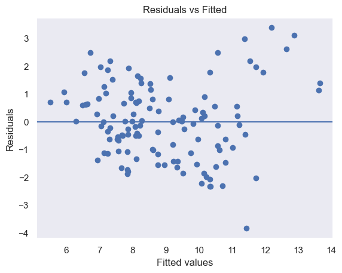

```python
fitted = model.fittedvalues
residuals = model.resid

plt.scatter(fitted, residuals)
plt.axhline(y=0)
plt.xlabel("Fitted values")
plt.ylabel("Residuals")
plt.title("Residuals vs Fitted")
plt.show()
```

```python
""" The Residuals vs Fitted plot checks if prediction errors are random — a random scatter around zero means the model fits well.
 In this case they are more or less good sign"""
```

```
' The Residuals vs Fitted plot checks if prediction errors are random — a random scatter around zero means the model fits well.\n In this case they are more or less good sign'
```